# Monte Carlo Error Simulation

Hongyu Dai

2021/9/11

# 1 Introduction

## 1.1 What’s Monte Carlo Error?

Statistical experiments, more commonly referred to as Monte Carlo or simulation studies, are used to study the behavior of statistical methods and measures under controlled situations. Whereas recent computing and methodological advances have permitted increased efficiency in the simulation process, such experiments remain limited by their finite nature and hence are subject to uncertainty; when a simulation is run more than once, different results are obtained. This kind of uncertainty, we refer to here as Monte Carlo Error.

Simulation generates approximate answers; there is some degree of error in a quantity estimated by Monte Carlo simulation. Intuitively, it seems that the degree of error should get smaller as the number of simulation replicates increases.

## 1.2 Why Monte Carlo Error is so important?

Because Monte Carlo simulation is widely used in various research, understanding the error of Monte Carlo simulation is of great significance for the analysis of experimental results.

## 1.3 What contains in this blog?

In this blog, I will demonstrate the concepts of absolute error and relative error when estimating probabilities from simulation, and investigate the relationship between then number of replicates and simulation error.

# 2 Background

## 2.1 Key Terms

| Parameter | Description | value |
| --- | --- | --- |
| **N** | number of replicate | 2^2, 2^3, …,2^15 |
| **P** | probability of success on each replicate | 0.01, 0.05, 0.10, 0.25, 0.50 |
| **r** | number of observations. If length(n) > 1, the length is taken to be the number required. | 10000 |
| **p̂** | the probability estimated from simulatio |  |
| **p** | the true underlying probability |  |
| **absolute error** | a measure of how far ‘off’ a measurement is from a true value or an indication of the uncertainty in a measurement. | abs_error=$\|p̂−p\|$ |
| **relative error** | how large the absolute error is compared with the total size of the object you are measuring. | rel_error = $\|p̂−p\|/p$ |

## 2.2 Coding language and required function

In this blog, we are going to use R markdown software, and the package and function we needed is as follow:

```r
require(tidyverse)


#' Setup a plot
#'
#' Sets up a plot based on variables in a dataset.  The intended use is for chained/piped commands.  Returns the same dataset that was passed in.
#' @param d A data.frame.
#' @param f Optional. A formula y ~ x. The limits of the plot region is calculated from the range of y and x.
#' @param xlim Optional. A 2 element vector, the limits of the x axis.
#' @param ylim Optional. A 2 element vector, the limits of the y axis.
#' @param log,asp,xaxs,yaxs Optional. Options sent in the plot.window command
#' @param ... Optional. Options sent to the par command
#' @keywords plot_setup
#' @export
#' @examples
#' iris %>%
#'   plot_setup(Sepal.Length~Sepal.Width) %>%
#'   split(.$Species) %>%
#'   lwith({
#'     l1 <- lm(Sepal.Length~Sepal.Width)
#'     lines(Sepal.Width, predict(l1))
#'   })

plot_setup <- function(d, f, xlim = NULL, ylim = NULL, log = "", asp = NA, xaxs = "r", yaxs = "r", ...){
  #browser()
  if(is.null(f)){
    v <- 1:4; dim(v) <- c(2,2)
  }else{
    v <- model.frame(f, data = d) %>% apply(2, range)
  }

  if(is.null(xlim)) xlim <- v[,2]
  if(is.null(ylim)) ylim <- v[,1]
  plot.new()
  par(...)
  plot.window(xlim = xlim, ylim = ylim, log = log, asp = asp, xaxs = xaxs, yaxs = yaxs)
  d
}


#' Commands repeated on each list element
#'
#' Repeats a set of commands for each element of a list.  The commands are executed within the \code{with} command, so that variable names need not be quoted.
#' @param l A list.  Each element of the list is a data.frame.
#' @param ... A set of commands to be executed
#' @keywords lwith
#' @seealso \code{\link{with}}
#' @export
#' @examples
#' iris %>%
#'   split(.$Species) %>%
#'   lwith({plot(Sepal.Length, Sepal.Width, main = Species[1])})

lwith <- function(l, ...) lapply(l, function(x, ...){with(x, ...)}, ... )
```

# 3 Simulation

## 3.1 14 X 5 factorial experiment simulation

In order to simulate Monte Carlo Error, first we need to perform a 14 X 5 factorial experiment simulation that estimates the error for each combination of replicate number (2^2, 2^3, …, 2^15) and probability (0.01, 0.05, 0.10, 0.25, 0.50).

The result matrix is shown as **output**:

```r
output <- expand.grid(
  N = 2^c(2:15)
  , P = c(0.01, 0.05, 0.10, 0.25, 0.50)
  , abs_error= NA
  , rel_error= NA
  , KEEP.OUT.ATTRS = FALSE
)

r <- 10000
for (i in 1:nrow(output)){
  p= output$P[i]
  n= output$N[i]
  phat <- rbinom(r,n,p)/n
  output[i,"abs_error"] <-mean(abs(phat-p))
  output[i,"rel_error"] <-mean(abs(phat-p)/p)
}

output
```

```
##        N    P    abs_error   rel_error
## 1      4 0.01 0.0196050000 1.960500000
## 2      8 0.01 0.0189850000 1.898500000
## 3     16 0.01 0.0169930000 1.699300000
## 4     32 0.01 0.0145102500 1.451025000
## 5     64 0.01 0.0105899375 1.058993750
## 6    128 0.01 0.0071131875 0.711318750
## 7    256 0.01 0.0050487813 0.504878125
## 8    512 0.01 0.0034717813 0.347178125
## 9   1024 0.01 0.0024745352 0.247453516
## 10  2048 0.01 0.0017655645 0.176556445
## 11  4096 0.01 0.0012388057 0.123880566
## 12  8192 0.01 0.0008843174 0.088431738
## 13 16384 0.01 0.0006190623 0.061906226
## 14 32768 0.01 0.0004367944 0.043679443
```

[output cut: 56 more lines]

In order to investigate the relationship between then number of replicates and simulation error, it will be shown by plotting the relationship between the number of replications and the error, as following:

## 3.2 Absoulte Error in log2 scale

```r
output %>%
  mutate (x=log2(N)) %>%
  mutate(col =as.factor(P) %>% as.numeric ) %>%
  plot_setup(abs_error ~ x,c(0,15)) %>%
  split(.$P) %>%
  lwith({
    lines(x,abs_error,col=col[1],lwd=2,type='b',pch=16)
    text(x[1],abs_error[1], paste0("p = ", P[1]),adj = c(1.1, 1))
    title(main = "Absoulte Error in log2 scale",xlab = "N(log2 scale)", ylab = " Absolute Error")
  })
```

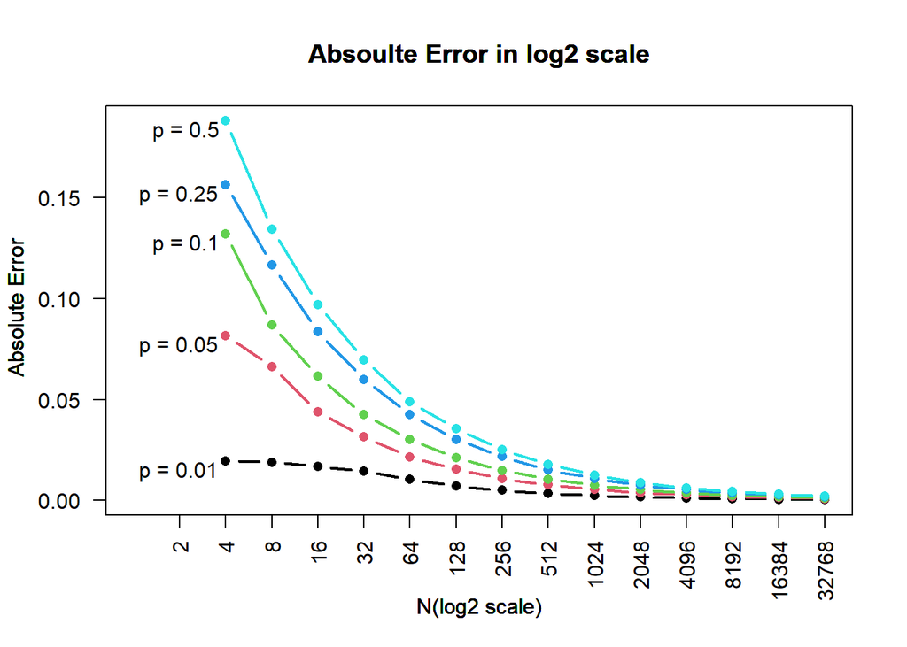

```r
axis(2,las=2)
axis(1,at=c(1:15),labels=2^c(1:15),las=2)
box()
```

From the above graph, it can be found that:

- The larger the value of p, the larger the Absoulte Error.
- As the number of replications increases, the Absoulte Error decreases until it approaches 0.
- The rate of change of Absoulte Error decreases as the number of replications increases.
- When p = 0.01, the absolute error is the smallest, and when p = 0.5, the absolute error is the largest.

## 3.3 Relative Error in log2 scale

```r
output %>%
  mutate (x=log2(N)) %>%
  mutate(col =as.factor(P) %>% as.numeric ) %>%
  plot_setup(rel_error ~ x,xlim=c(0,16),ylim=c(0,2)) %>%
  split(.$P) %>%
  lwith({
    lines(x,rel_error,col=col[1],lwd=2,type='b',pch=16)
    text(x[1],rel_error[1], paste0("p = ", P[1]),adj = c(1.1, 1))
    title(main = "Relative Error in log2 scale", xlab = "N (log2 scale)", ylab = "Relative Error")
  })
```

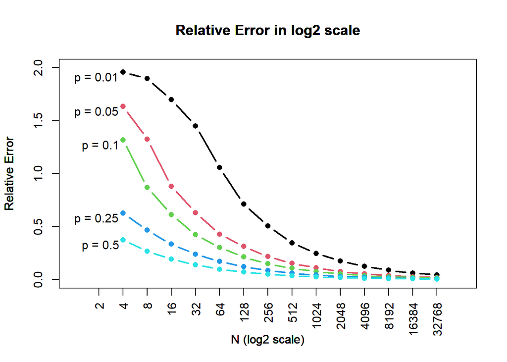

```r
axis(2)
axis(1,at=c(1:15),labels=2^c(1:15),las=2)
box()
```

## 3.4 Result in log10 scale

We can also generate the results with the y-axis is on the log10 scale.

It can be found that the obtained image has a similar decreasing trend to that on the log2 scale: as the number of replications increases, the absolute/relative error decreases. In addition, there is an approximately linear relationship between the number of replications and the absolute/relative error.

### 3.4.1 Absoulte Error in log10 scale

```r
output %>%
  mutate (x=log2(N)) %>%
  mutate(abs_error=log10(abs_error))%>%
  mutate(col =as.factor(P) %>% as.numeric ) %>%
  plot_setup(abs_error ~ x,c(0,15)) %>%
  split(.$P) %>%
  lwith({
    lines(x,abs_error,col=col[1],lwd=2,type='b',pch=16)
    text(x[1],abs_error[1], paste0("p = ", P[1]),adj = c(1.1, 1))
    title(main = "Absoulte Error in log10 scale",xlab = "N(log2 scale)", ylab = " Absolute Error (log10 scale)")
    })
```

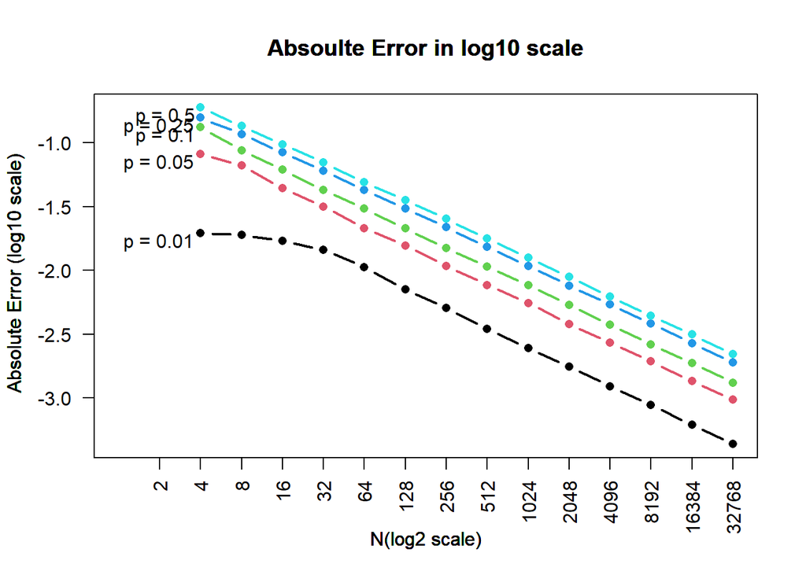

```r
axis(2,las=2)
axis(1,at=c(1:15),labels=2^c(1:15),las=2)
box()
```

### 3.4.2 Relative Error in log10 scale

```r
output %>%
  mutate (x=log2(N)) %>%
  mutate(rel_error=log10(rel_error))%>%
  mutate(col =as.factor(P) %>% as.numeric ) %>%
  plot_setup(rel_error ~ x,xlim=c(0,16)) %>%
  split(.$P) %>%
  lwith({
    lines(x,rel_error,col=col[1],lwd=2,type='b',pch=16)
    text(x[1],rel_error[1], paste0("p = ", P[1]),adj = c(1.1, 1))
    title(main = "Relative Error in log10 scale", xlab = "N (log2 scale)", ylab = "Relative Error (log10 scale)")
  })
```

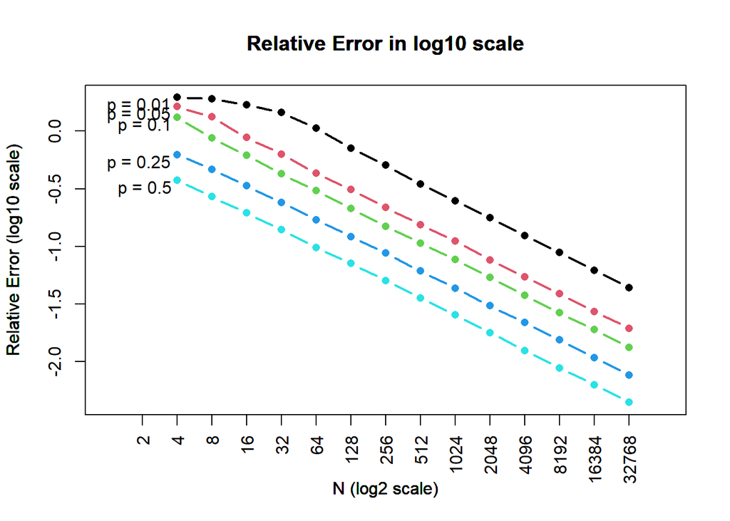

```r
axis(2)
axis(1,at=c(1:15),labels=2^c(1:15),las=2)
box()
```

## 3.5 Conclusion

In conclusion, the values of both relative and absolute errors decrease as the number of replications increases.